# Campus_Recruitment_Analysis

Kathan Vakharia

03/08/2020

## Inroduction

This data set consists of Placement data of students in a XYZ campus. It includes secondary and higher secondary school percentage and specialization. It also includes degree specialization, type and Work experience and salary offers to the placed students

The data set can be found [here](https://www.kaggle.com/benroshan/factors-affecting-campus-placement/data?select=Placement_Data_Full_Class.csv).

```r
#Initial Setup
library(tidyverse)
placement_data <- read.csv("campus_recruitment/Placement_Data_Full_Class.csv")
summary(placement_data)
```

```
##      sl_no          gender              ssc_p          ssc_b
##  Min.   :  1.0   Length:215         Min.   :40.89   Length:215
##  1st Qu.: 54.5   Class :character   1st Qu.:60.60   Class :character
##  Median :108.0   Mode  :character   Median :67.00   Mode  :character
##  Mean   :108.0                      Mean   :67.30
##  3rd Qu.:161.5                      3rd Qu.:75.70
##  Max.   :215.0                      Max.   :89.40
##
##      hsc_p          hsc_b              hsc_s              degree_p
##  Min.   :37.00   Length:215         Length:215         Min.   :50.00
##  1st Qu.:60.90   Class :character   Class :character   1st Qu.:61.00
##  Median :65.00   Mode  :character   Mode  :character   Median :66.00
##  Mean   :66.33                                         Mean   :66.37
##  3rd Qu.:73.00                                         3rd Qu.:72.00
##  Max.   :97.70                                         Max.   :91.00
##
##    degree_t            workex             etest_p     specialisation
##  Length:215         Length:215         Min.   :50.0   Length:215
##  Class :character   Class :character   1st Qu.:60.0   Class :character
##  Mode  :character   Mode  :character   Median :71.0   Mode  :character
##                                        Mean   :72.1
##                                        3rd Qu.:83.5
##                                        Max.   :98.0
##
##      mba_p          status              salary
##  Min.   :51.21   Length:215         Min.   :200000
##  1st Qu.:57.95   Class :character   1st Qu.:240000
##  Median :62.00   Mode  :character   Median :265000
##  Mean   :62.28                      Mean   :288655
##  3rd Qu.:66.25                      3rd Qu.:300000
##  Max.   :77.89                      Max.   :940000
##                                     NA's   :67
```

### Getting overview of columns

```r
glimpse(placement_data)
```

```
## Rows: 215
## Columns: 15
## $ sl_no          <int> 1, 2, 3, 4, 5, 6, 7, 8, 9, 10, 11, 12, 13, 14, 15, 1...
## $ gender         <chr> "M", "M", "M", "M", "M", "M", "F", "M", "M", "M", "M...
## $ ssc_p          <dbl> 67.00, 79.33, 65.00, 56.00, 85.80, 55.00, 46.00, 82....
## $ ssc_b          <chr> "Others", "Central", "Central", "Central", "Central"...
## $ hsc_p          <dbl> 91.00, 78.33, 68.00, 52.00, 73.60, 49.80, 49.20, 64....
## $ hsc_b          <chr> "Others", "Others", "Central", "Central", "Central",...
## $ hsc_s          <chr> "Commerce", "Science", "Arts", "Science", "Commerce"...
## $ degree_p       <dbl> 58.00, 77.48, 64.00, 52.00, 73.30, 67.25, 79.00, 66....
## $ degree_t       <chr> "Sci&Tech", "Sci&Tech", "Comm&Mgmt", "Sci&Tech", "Co...
## $ workex         <chr> "No", "Yes", "No", "No", "No", "Yes", "No", "Yes", "...
## $ etest_p        <dbl> 55.00, 86.50, 75.00, 66.00, 96.80, 55.00, 74.28, 67....
## $ specialisation <chr> "Mkt&HR", "Mkt&Fin", "Mkt&Fin", "Mkt&HR", "Mkt&Fin",...
## $ mba_p          <dbl> 58.80, 66.28, 57.80, 59.43, 55.50, 51.58, 53.29, 62....
## $ status         <chr> "Placed", "Placed", "Placed", "Not Placed", "Placed"...
## $ salary         <int> 270000, 200000, 250000, NA, 425000, NA, NA, 252000, ...
```

So we can see there are `215` rows and `15` columns in this data set.

```r
#getting column names
col_vector <- colnames(placement_data)
print(col_vector)
```

```
##  [1] "sl_no"          "gender"         "ssc_p"          "ssc_b"
##  [5] "hsc_p"          "hsc_b"          "hsc_s"          "degree_p"
##  [9] "degree_t"       "workex"         "etest_p"        "specialisation"
## [13] "mba_p"          "status"         "salary"
```

```r
#getting column's data types
for(col in col_vector){
   print(str_c(col,": ", typeof(placement_data[[col]])))
}
```

```
## [1] "sl_no: integer"
## [1] "gender: character"
## [1] "ssc_p: double"
## [1] "ssc_b: character"
## [1] "hsc_p: double"
## [1] "hsc_b: character"
## [1] "hsc_s: character"
## [1] "degree_p: double"
## [1] "degree_t: character"
## [1] "workex: character"
## [1] "etest_p: double"
## [1] "specialisation: character"
## [1] "mba_p: double"
## [1] "status: character"
## [1] "salary: integer"
```

```r
#Let's find unique values of categorical attributes

for(col in col_vector){
  if(typeof(placement_data[[col]]) == "character"){
    unq_values <- placement_data %>%
      pull(col)  %>%
      unique
    n <- length(unq_values)
    print(str_c( n," unique values for ", col, ":"))
    print(unq_values)
  }
}
```

```
## [1] "2 unique values for gender:"
## [1] "M" "F"
## [1] "2 unique values for ssc_b:"
## [1] "Others"  "Central"
## [1] "2 unique values for hsc_b:"
## [1] "Others"  "Central"
## [1] "3 unique values for hsc_s:"
## [1] "Commerce" "Science"  "Arts"
## [1] "3 unique values for degree_t:"
## [1] "Sci&Tech"  "Comm&Mgmt" "Others"
## [1] "2 unique values for workex:"
## [1] "No"  "Yes"
## [1] "2 unique values for specialisation:"
## [1] "Mkt&HR"  "Mkt&Fin"
## [1] "2 unique values for status:"
## [1] "Placed"     "Not Placed"
```

## Getting Insights

- Let’s analyze our data to find out, what factors lead to better placements

### 1. On based of PG program

Instead of looking at number of placements, it is better to see the how many percent of total students for a particular specialization got placed.

```r
#Checking total of students for a specific specialization
placement_data %>%
  group_by(specialisation)%>%
  summarise(
    total_students = n(),
    .groups = "drop"
  )
```

```
## # A tibble: 2 x 2
##   specialisation total_students
##   <chr>                   <int>
## 1 Mkt&Fin                   120
## 2 Mkt&HR                     95
```

```r
#Checking total students placed for specific specialisation
placement_data%>%
  filter(
    status == "Placed"
  )%>%
  group_by(specialisation)%>%
  summarise(
    total_students = n(),
    .groups = "drop"
  )
```

```
## # A tibble: 2 x 2
##   specialisation total_students
##   <chr>                   <int>
## 1 Mkt&Fin                    95
## 2 Mkt&HR                     53
```

We can see , that number of students enrolled in

> Marketing & Finance are `120` , `95` - placed  
> Marketing & Human Resoure are `95`, `53` - placed

```r
library(janitor)
#storing results in a  named vector
n_students <- c("Mkt&Fin"=120, "Mkt&HR"=95)
n_students_placed <- c("Mkt&Fin"=95, "Mkt&HR"=53)
total_students <- sum(n_students)
total_students_placed <- nrow(
  placement_data %>% filter(status=="Placed")
)

#getting insights based on specialization

placement_data %>%
    filter(
    status == "Placed"
  )%>%
  group_by(specialisation) %>%
  summarise(
    total_placed = n(),
    total_prop = n() / total_students,
    total_prop_by_placed = total_placed/total_students_placed,
    .groups = "drop"
  )%>%
  adorn_totals("row")
```

```
##  specialisation total_placed total_prop total_prop_by_placed
##         Mkt&Fin           95  0.4418605            0.6418919
##          Mkt&HR           53  0.2465116            0.3581081
##           Total          148  0.6883721            1.0000000
```

- We can see that nearly **69%**(`148`) of total students(`215` ) were placed, out of which students enrolled in Marketing and Finance were **44%(approx)** and students enrolled in Marketing and HR were **25%(approx)**
- Also, out of total students placed,nearly **64%** are from Marketing & Finance and nearly **36%** are from Marketing & HR.
- It gives a conclusion that more students are getting placed from *Marketing And Finance* specialization
- Still it is not clear, what is the placement ratio of students in each specialization. Let’s find that next

```r
#Getting proportion of placements for a particular specialization

placement_data %>%
   filter(
    status == "Placed"
  )%>%
  group_by(specialisation)%>%
  summarise(
    total_placed = n(),
    .groups="drop"
  )%>%
  mutate(
    total_prop_by_spec = total_placed / case_when(
      specialisation == "Mkt&Fin" ~ n_students[1],
      specialisation == "Mkt&HR" ~ n_students[2]
    ),
  )
```

```
## # A tibble: 2 x 3
##   specialisation total_placed total_prop_by_spec
##   <chr>                 <int>              <dbl>
## 1 Mkt&Fin                  95              0.792
## 2 Mkt&HR                   53              0.558
```

- It is evident that nearly **79%** of total students in *Marketing and Finance* are getting placed, while nearly **56%** of total students in *Marketing and Human Resource* are getting placed
- We conclude that students enrolled in *Marketing and Finance* are more likely to get placed

### 2. Based on Gender

Let’s see if there is any relation b/w `gender` and `status`.

```r
#getting proportion of placement based on gender

placement_data %>%
  filter(
    status == "Placed"
  )%>%
  group_by(gender)%>%
  summarise(
    total = n(),
    .groups = "drop"
  )%>%
  mutate(
    total_prop = total/total_students_placed
  )
```

```
## # A tibble: 2 x 3
##   gender total total_prop
##   <chr>  <int>      <dbl>
## 1 F         48      0.324
## 2 M        100      0.676
```

- It is evident that **32%** of total students placed are female and **68%** of the are males.
- Hence , we can say placement of males is more.

Now, let’s see their proportion based on specialization

```r
placement_data %>%
  filter(
    status == "Placed"
  )%>%
  group_by(specialisation, gender) %>%
  summarise(
    total_placed = n(),
    .groups = "drop"
  )%>%
  mutate(
    total_prop = total_placed / case_when(
      specialisation == "Mkt&Fin" ~ n_students_placed[1],
      specialisation == "Mkt&HR" ~ n_students_placed[2]
    )
  )
```

```
## # A tibble: 4 x 4
##   specialisation gender total_placed total_prop
##   <chr>          <chr>         <int>      <dbl>
## 1 Mkt&Fin        F                28      0.295
## 2 Mkt&Fin        M                67      0.705
## 3 Mkt&HR         F                20      0.377
## 4 Mkt&HR         M                33      0.623
```

- So, we can say that placement of males is more than females in both the specialization but it’s slightly less in case of **Marketing and HR**

### 3.Visualizing salary distribution

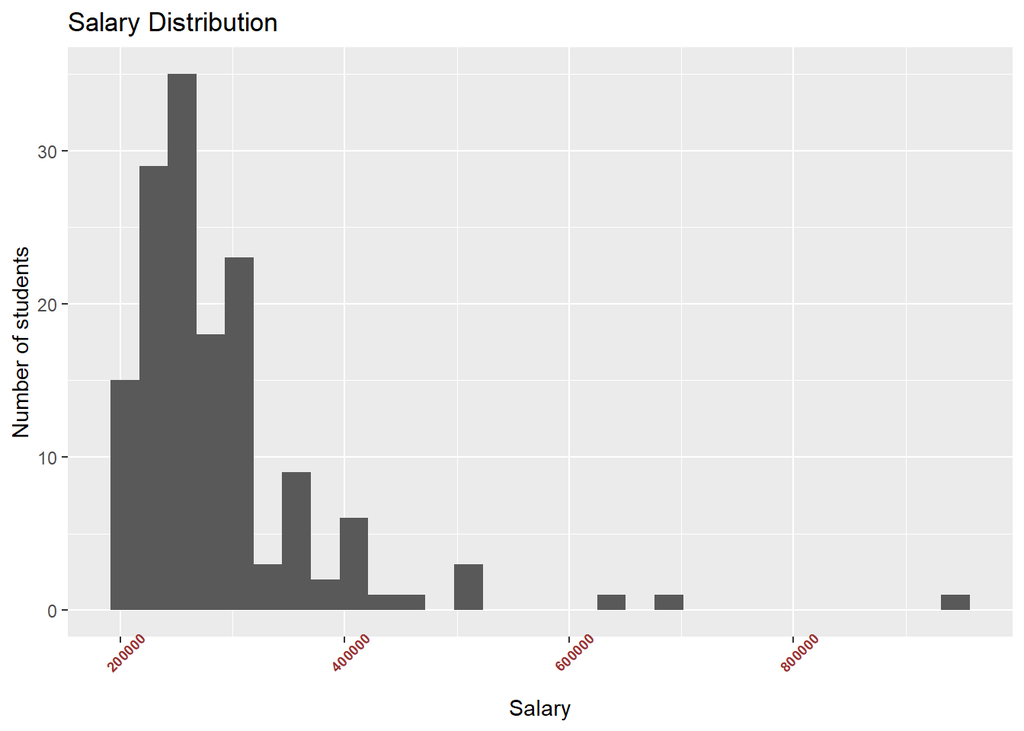

```r
options(scipen = 10000)
placement_data %>%
  filter(status == "Placed")%>%
  ggplot(
    aes(x = salary)
  ) +
  labs(title = "Salary Distribution")+
  xlab("Salary")+
  ylab("Number of students")+
  geom_histogram(bins = 30)+
  theme(axis.text.x = element_text(face="bold", color="#993333",
                           size=7, angle=45)
  )
```

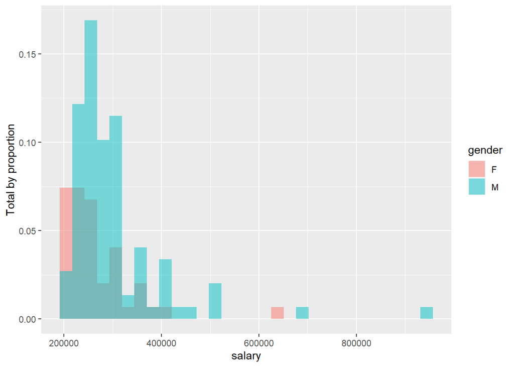

```r
#Checking salaries' distribution of males and females
placement_data %>%
  filter(
    status=="Placed",
  )%>%
  ggplot(
    aes(x=salary,
        fill=gender)
  )+
  geom_histogram(bins=30, alpha=0.5, position = "identity",
                 aes(y=..count../sum(..count..)))+
  ylab("Total by proportion")
```

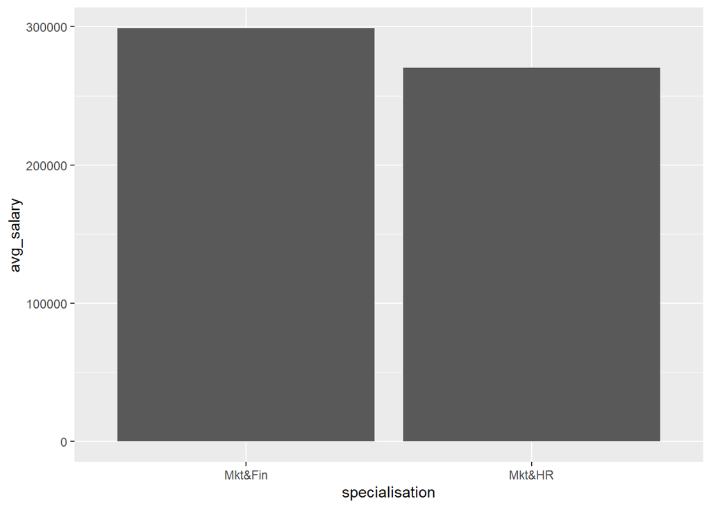

```r
#checking which specilisation has higher salary
placement_data %>%
  filter(
    status=="Placed",
  )%>%
  group_by(
    specialisation
  )%>%
  summarise(
    avg_salary = mean(salary),
    .groups = "drop"
  )%>%
  ggplot(
    aes(x=specialisation,
        y=avg_salary
        )
  )+
  geom_bar(
    stat="identity"
  )
```

### 4.Salary Vs WorkExperience

1. Salary Vs total placements

```r
#Finding prop by work exp
placement_data %>%
  filter(
    status=="Placed"
  )%>%
  group_by(workex)%>%
  summarise(
    total_students = n(),
    total_students_by_prop = total_students/total_students_placed,
    .groups = "drop"
  )%>%
  adorn_totals("row")
```

```
##  workex total_students total_students_by_prop
##      No             84              0.5675676
##     Yes             64              0.4324324
##   Total            148              1.0000000
```

```r
#Analysis salaries of students having no work exp
summary(
  placement_data %>%
    filter(
      status == "Placed",
      workex == "No"
    )%>%
    select(
      salary
    )
)
```

```
##      salary
##  Min.   :200000
##  1st Qu.:240000
##  Median :262000
##  Mean   :277524
##  3rd Qu.:300000
##  Max.   :500000
```

```r
#Analysis salaries of students having  work exp
summary(
  placement_data %>%
    filter(
      status == "Placed",
      workex == "Yes"
    )%>%
    select(salary)
)
```

```
##      salary
##  Min.   :200000
##  1st Qu.:250000
##  Median :267500
##  Mean   :303266
##  3rd Qu.:300000
##  Max.   :940000
```

- So, we can say that although the mean of students getting placed is more there’s not much difference in salaries of students having work experience with those who are not.
- Let’s see the box plot to make things more clear

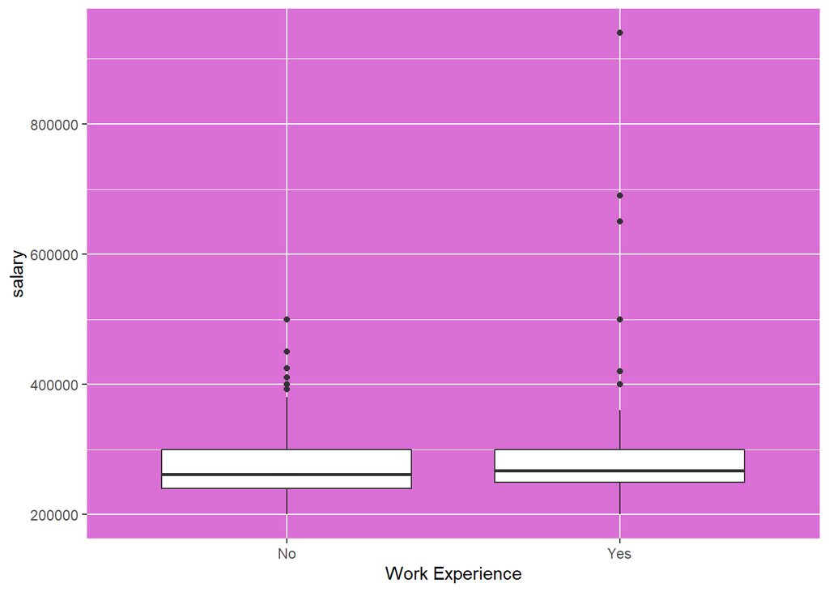

```r
placement_data_placed <- placement_data %>% filter(status=="Placed")
create_box <- function( x, y){
  ggplot(data= placement_data_placed,
         aes_string(x=x,
                    y=y
                    )
         )+
    geom_boxplot()+
    theme(panel.background = element_rect("orchid"))
}

create_box("workex","salary") +
  xlab("Work Experience")
```

- We can see the `IQR` of both is almost similar, the reason for students with `workexp` having higher `avg salary` is due to some higher salaries of students having work experience.

```r
#Getting salary depending on Gender

#male
summary(
placement_data_placed %>%
  filter(gender=="M")%>%
  select(salary)
)
```

```
##      salary
##  Min.   :200000
##  1st Qu.:250000
##  Median :270000
##  Mean   :298910
##  3rd Qu.:300000
##  Max.   :940000
```

```r
#female
summary(
placement_data_placed %>%
  filter(gender=="F")%>%
  select(salary)
)
```

```
##      salary
##  Min.   :200000
##  1st Qu.:219500
##  Median :250000
##  Mean   :267292
##  3rd Qu.:300000
##  Max.   :650000
```

- Seems like males are getting more salary with respect to females.Let’s make our point clear by box plot.

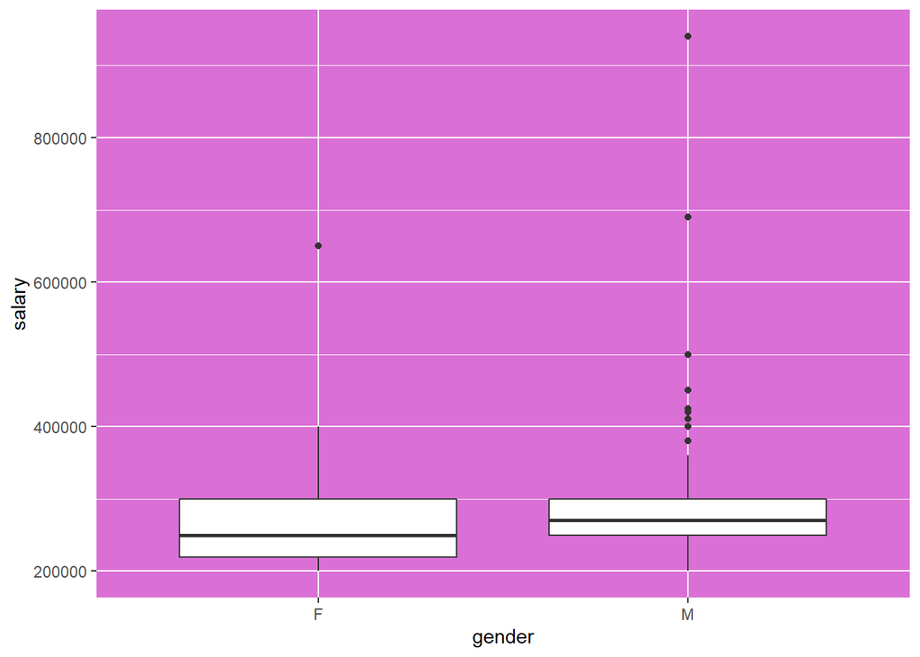

```r
create_box("gender", "salary")
```

- There are many outliers in case of males but overall we can say males are getting more salary.

### 5. HSC percentage VS Salary

Let’s end our analysis by finding relation between the hsc percentage and the salary.

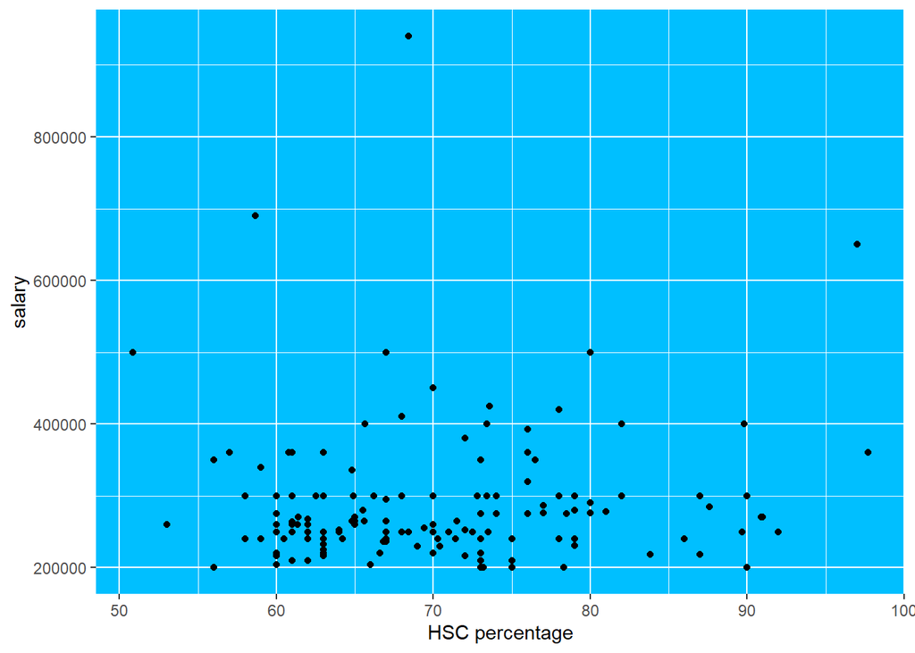

```r
create_scatter <- function(x, y){
  ggplot(data=placement_data_placed,
         aes_string(
           x=x,
           y=y
         ))+
    geom_point()+
    theme(panel.background = element_rect(fill = "deepskyblue1"))
}
create_scatter("hsc_p", "salary")+
  xlab("HSC percentage")
```

- Looking at the scatter plot, it is clear there is not relation between `hsc percentage` and `amount of salary`.
- let’s see if there is any relation with MBA percentage and emp test.

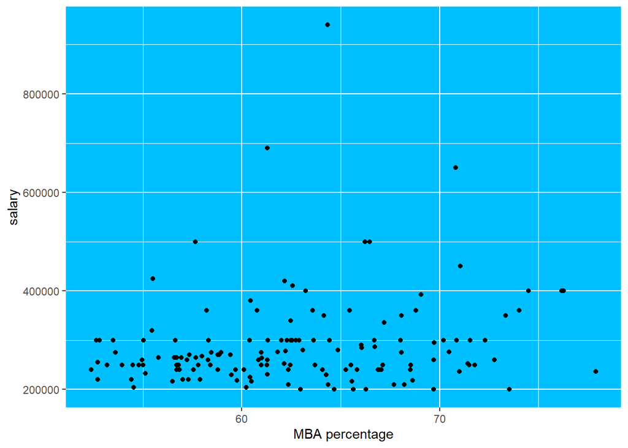

```r
#salary vs mba per
create_scatter("mba_p", "salary")+
  xlab("MBA percentage")
```

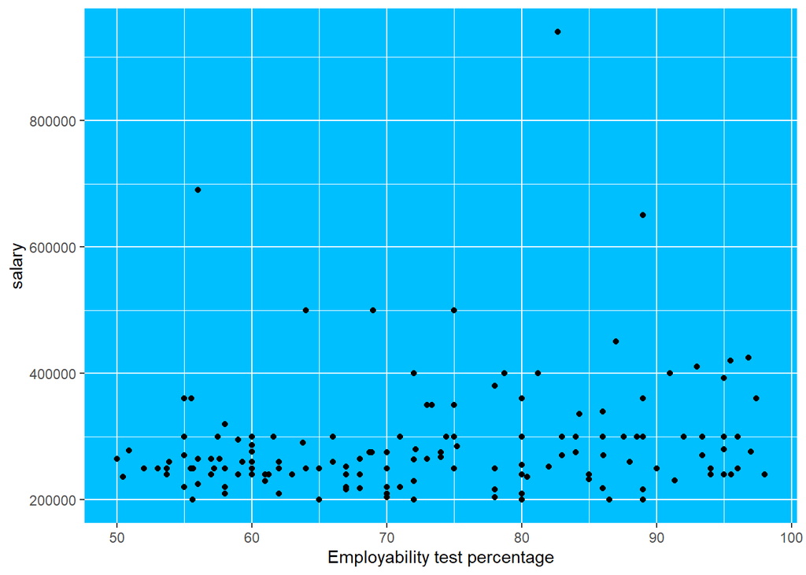

```r
#salary vs etest per
create_scatter("etest_p", "salary")+
  xlab("Employability test percentage")
```

- So, it is evident *`Percentage doesn't matter`*.

## Conclusion

> Limitations : There were only 215 rows so it might not tell the whole story